# H06 Stage 2: implementation, diagnostics, and V0 comparison

Nature Health analysis audit — H06-G2 author-review gate

Published

August 10, 2026

**WarningStage 2 result gate — author review required**

This report implements the author-approved H06-002 population-mean contract. All planned models are numerically estimable, but the diagnostics show substantial overdispersion, imperfect mean calibration, and residual within-day and local-clock structure. The activity association is stable across the declared checks. The work/free association is positive in the primary analysis but is sensitive to the working variance and to omitting two sites. The sleep interval includes both a modest decrease and a modest increase. These are **provisional audit results, not accepted manuscript claims**. Stage 3 remains blocked until explicit H06-G2 approval.

# Question and controlling contract

The preregistered hypothesis is:

> **H6: Day type, daily exercise, and sleep variables predict daily light exposure metrics.**

DEV-015 records a deliberate adaptation: the registered 15-metric, participant-day question was judged insufficiently parsimonious and interpretable, so the selected analysis asks about supported one-hour zero-aware geometric mean melEDI. This deliberate choice is not treated as an error. It does change the outcome, analysis unit, weighting of days, temporal dependence, multiplicity family, and reader-facing wording. The revised analysis therefore estimates expected hourly melEDI across retained supported hours; it does not test “daily exposure.”

The primary predictors are work/free day, binary activity status (sedentary versus any light, moderate, or vigorous reported exercise), and previous-night sleep duration. Near-eye is primary. Chest, exact paired-day refits, weekday/weekend, the gap comparison, alternative covariance and working-variance choices, and targeted deletions have their declared supporting roles. Local clock is not a confirmatory covariate because the author requested an average across retained supported hours; exploratory GAMs separately describe time of day.

## Immutable inputs and identity check

All 15 contract inputs match their approved SHA-256 identities, including the revised Stage 1 source `393fd87c908302c1681925dcc451b27be31e652758592da8a81c775ff09aaf26`, its render `186ab355deb0ba41f276c55c0490e9e0edbe7be1060c40fe2f4c366ed8eee8ae`, and decision H06-002 `882057ec11ce5e6a56d5b7268b3b501d372c2ec5a34de21a1ef0fa4ebcf07a52`. The analytical TUM diary source remains the immutable `melidosData` 1.0.6 pin (commit `618fda8521f3cf581661ceb2c026e3de7cd9ba82`, DOI `10.5281/zenodo.16893901`, object SHA-256 `0db56324e9826d427c42984fdfc43eb1e7487211365f222a1c0b2ecff618f1ef`). The read-only assertion finds **7 TUM S001 rows and 0 S101 rows**, with no local identifier rewrite. No remote release was fetched and no shared preparation was rebuilt.

The `KNUST_S005` source numeral 3,600 is interpreted only in the exploratory H06 adapter as 3,600 seconds = 1 hour. The shared diary is unchanged; this row does not enter the primary analysis.

Consequential software versions for H06 Stage 2.

| Package | Version |
| --- | --- |
| R | 4.6.1 |
| sandwich | 3.1.1 |
| statmod | 1.5.2 |
| glmmTMB | 1.1.14 |
| performance | 0.17.1 |
| emmeans | 2.0.3 |
| LightLogR | 0.10.3 |

R is the authoritative analytical language.

# Exact models and inference

The mean is fitted with a zero-inclusive quasi-Poisson log-link GLM. Participant-cluster HC3 covariance (`fix = FALSE`, finite-cluster correction) treats participants—not hours—as inferential replicates. One-coefficient tests use a *t* reference with *G* − 1 degrees of freedom; multi-coefficient site-interaction tests use Wald *F* with restriction-rank and *G* − 1 degrees of freedom. Fixed site is sum-coded. Overall ratios are equal-site averages on the linear-predictor scale followed by one exponential back-transformation. The covariance permits arbitrary dependence within participant, but it does not whiten residuals or repair the conditional mean.

```r
formula_text <- function(x) paste(deparse(x), collapse = " ")

formula_registry <- tibble::enframe(
  h06_formula_set(), name = "model_id", value = "formula"
) |>
  dplyr::mutate(formula = vapply(.data$formula, formula_text, character(1)))

formula_registry |>
  dplyr::mutate(
    role = dplyr::case_when(
      .data$model_id == "additive" ~ "Primary mean and H06-F1/F3",
      .data$model_id == "full" ~ "Site heterogeneity and H06-F2",
      grepl("additive_no", .data$model_id) ~ "Visible hierarchy-preserving reduced model",
      grepl("full_no", .data$model_id) ~ "Visible interaction-block reduced model",
      .data$model_id == "weekend_additive" ~ "Estimate/CI sensitivity only",
      TRUE ~ "Construction reference"
    )
  ) |>
  dplyr::select(Model = .data$model_id, Role = .data$role,
                `Evaluated Wilkinson formula` = .data$formula) |>
  compact_gt(
    source_note = paste0(
      "All comparisons use identical frozen rows. Quasi-likelihood AIC and ",
      "likelihood-ratio tests are unavailable and are not reported."
    )
  )
```

| Model | Role | Evaluated Wilkinson formula |
| --- | --- | --- |
| base | Construction reference | response_value ~ site |
| additive | Primary mean and H06-F1/F3 | response_value ~ site + work_free_day + activity_status + previous_sleep_duration_centered_h |
| additive_no_daytype | Visible hierarchy-preserving reduced model | response_value ~ site + activity_status + previous_sleep_duration_centered_h |
| additive_no_activity | Visible hierarchy-preserving reduced model | response_value ~ site + work_free_day + previous_sleep_duration_centered_h |
| additive_no_sleep | Visible hierarchy-preserving reduced model | response_value ~ site + work_free_day + activity_status |
| full | Site heterogeneity and H06-F2 | response_value ~ site * work_free_day + site * activity_status + site * previous_sleep_duration_centered_h |
| full_no_daytype_interaction | Visible interaction-block reduced model | response_value ~ site + work_free_day + activity_status + previous_sleep_duration_centered_h + site:(activity_status + previous_sleep_duration_centered_h) |
| full_no_activity_interaction | Visible interaction-block reduced model | response_value ~ site + work_free_day + activity_status + previous_sleep_duration_centered_h + site:(work_free_day + previous_sleep_duration_centered_h) |
| full_no_sleep_interaction | Visible interaction-block reduced model | response_value ~ site + work_free_day + activity_status + previous_sleep_duration_centered_h + site:(work_free_day + activity_status) |
| weekend_additive | Estimate/CI sensitivity only | response_value ~ site + weekday_weekend + activity_status + previous_sleep_duration_centered_h |

All comparisons use identical frozen rows. Quasi-likelihood AIC and likelihood-ratio tests are unavailable and are not reported.

The active confirmatory multiplicity families each contain exactly three tests and use Benjamini–Hochberg adjustment. Raw p-values are displayed but never bolded. Only adjusted p-values at α = 0.050 are bolded. Chest, paired-placement, covariance, standardization, weekday/weekend, influence, and exploratory outputs do not create post hoc significance families.

Prespecified H06 multiplicity families.

| Family | Content | Size | Method |
| --- | --- | --- | --- |
| H06-F1-main | Primary near-eye main-association tests | 3 | BH |
| H06-F2-heterogeneity | Primary near-eye site-heterogeneity tests | 3 | BH |
| H06-F3-practical-contrasts | Primary equal-site practical contrasts | 3 | BH |
| H06-F1-gap | Gap-timing-unaware near-eye main tests | 3 | BH |
| H06-F2-gap | Gap-timing-unaware near-eye heterogeneity tests | 3 | BH |

# Exact fitted samples and category cells

The primary near-eye fit contains 16,596 supported hours from 715 participant-days, 137 participants, and all nine sites. Days contribute 19–24 supported hours, so the approved estimand is explicitly supported-hour weighted. Chest has 18,352 hours, 789 participant-days, 149 participants, and eight sites.

Exact fitted samples for every H06 Stage 2 core run.

| Scenario | Hours | Participant-days | Participants | Sites | Supported hours/day |
| --- | --- | --- | --- | --- | --- |
| Primary near-eye | 16,596 | 715 | 137 | 9 | 19–24 |
| Chest, all available | 18,352 | 789 | 149 | 8 | 19–24 |
| Near-eye, paired days | 12,842 | 553 | 109 | 8 | 19–24 |
| Chest, paired days | 12,842 | 553 | 109 | 8 | 19–24 |
| Gap sensitivity, near-eye | 16,329 | 702 | 137 | 9 | 20–24 |
| Gap sensitivity, chest | 18,112 | 777 | 149 | 8 | 20–24 |

Every row is frozen and hashed. Full exact site × category counts are stored in H06_category_cells.csv.

The primary site × day-type and site × activity table below keeps every cell visible. Across cells, the minima are 185 supported hours, 8 participant-days, and 4 participants; these minima do not all occur in the same cell. No category was merged after seeing an effect. Download the complete six-run cell registry.

Exact primary near-eye category cells by submitted site.

| Site | Category | Hours | Days | Participants |
| --- | --- | --- | --- | --- |
| Activity |  |  |  |  |
| Borås (SE) | Active (light, moderate, or vigorous exercise) | 1,076 | 46 | 13 |
| Borås (SE) | Sedentary (no reported exercise) | 559 | 24 | 11 |
| Delft (NL) | Active (light, moderate, or vigorous exercise) | 1,172 | 51 | 13 |
| Delft (NL) | Sedentary (no reported exercise) | 185 | 8 | 6 |
| Dortmund (DE) | Active (light, moderate, or vigorous exercise) | 1,558 | 67 | 17 |
| Dortmund (DE) | Sedentary (no reported exercise) | 486 | 21 | 12 |
| Tübingen (DE) | Active (light, moderate, or vigorous exercise) | 2,609 | 113 | 26 |
| Tübingen (DE) | Sedentary (no reported exercise) | 815 | 35 | 14 |
| Munich (DE) | Active (light, moderate, or vigorous exercise) | 856 | 37 | 9 |
| Munich (DE) | Sedentary (no reported exercise) | 534 | 23 | 8 |
| Madrid (ES) | Active (light, moderate, or vigorous exercise) | 1,259 | 54 | 18 |
| Madrid (ES) | Sedentary (no reported exercise) | 783 | 33 | 14 |
| Izmir (TR) | Active (light, moderate, or vigorous exercise) | 1,297 | 56 | 15 |
| Izmir (TR) | Sedentary (no reported exercise) | 938 | 40 | 13 |
| San José (CR) | Active (light, moderate, or vigorous exercise) | 208 | 9 | 5 |
| San José (CR) | Sedentary (no reported exercise) | 422 | 18 | 6 |
| Kumasi (GH) | Active (light, moderate, or vigorous exercise) | 1,565 | 68 | 15 |
| Kumasi (GH) | Sedentary (no reported exercise) | 274 | 12 | 8 |
| Day type |  |  |  |  |
| Borås (SE) | Free day | 630 | 27 | 13 |
| Borås (SE) | Work day | 1,005 | 43 | 12 |
| Delft (NL) | Free day | 434 | 19 | 11 |
| Delft (NL) | Work day | 923 | 40 | 13 |
| Dortmund (DE) | Free day | 840 | 36 | 17 |
| Dortmund (DE) | Work day | 1,204 | 52 | 17 |
| Tübingen (DE) | Free day | 1,430 | 62 | 25 |
| Tübingen (DE) | Work day | 1,994 | 86 | 26 |
| Munich (DE) | Free day | 693 | 30 | 10 |
| Munich (DE) | Work day | 697 | 30 | 10 |
| Madrid (ES) | Free day | 702 | 30 | 15 |
| Madrid (ES) | Work day | 1,340 | 57 | 19 |
| Izmir (TR) | Free day | 765 | 33 | 16 |
| Izmir (TR) | Work day | 1,470 | 63 | 17 |
| San José (CR) | Free day | 187 | 8 | 4 |
| San José (CR) | Work day | 443 | 19 | 6 |
| Kumasi (GH) | Free day | 923 | 40 | 14 |
| Kumasi (GH) | Work day | 916 | 40 | 14 |

# Primary near-eye results

Primary equal-site ratios of expected supported-hour melEDI.

| Predictor | Ratio (95% CI) | Raw p | BH-adjusted p |
| --- | --- | --- | --- |
| Free day versus work day | 1.45 × (1.14–1.85) | 0.003 | **0.004** |
| Active versus sedentary | 2.06 × (1.54–2.76) | <0.001 | **<0.001** |
| Previous sleep duration (per hour) | 0.98 × (0.85–1.12) | 0.745 | 0.745 |

Quasi-Poisson log mean; sum-coded fixed site; participant-cluster HC3; G = 137 and denominator df = 136. Ratios above 1 indicate higher expected hourly melEDI. Only adjusted p-values meeting alpha = 0.050 are bold.

In the primary analysis, expected supported-hour melEDI was 1.45 times as high on free days as on work days (95% CI 1.14–1.85; BH-adjusted p = 0.004) and 2.06 times as high on active as on sedentary days (1.54–2.76; BH-adjusted p < 0.001). The previous-sleep ratio was 0.98 per additional hour (0.85–1.12; BH-adjusted p = 0.745). The sleep interval is compatible with a modest decrease or increase; it is not evidence for “no effect.”

Primary site-interaction block tests.

| Predictor | Test | Raw p | BH-adjusted p |
| --- | --- | --- | --- |
| Free day versus work day | F(8, 136) = 2.87 | 0.006 | **0.017** |
| Active versus sedentary | F(8, 136) = 1.01 | 0.429 | 0.644 |
| Previous sleep duration (per hour) | F(8, 136) = 0.45 | 0.887 | 0.887 |

H06-F2 contains the three declared site-interaction blocks. Only the BH-adjusted p-value is eligible for bolding.

The work/free association varied across sites (BH-adjusted p = 0.017). Activity and sleep showed no multiplicity-retained site heterogeneity. The overall work/free ratio must therefore be presented with its site-specific variation rather than as a universal site-invariant contrast.

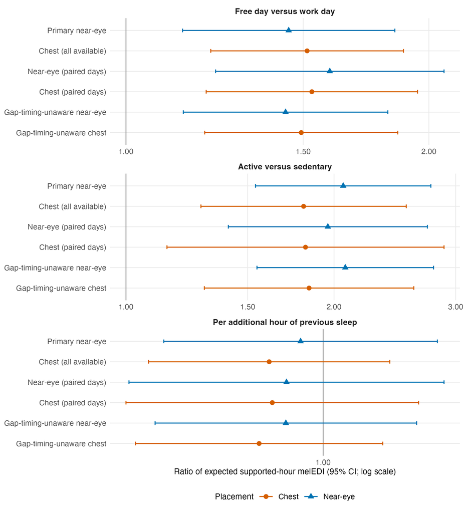

Core H06 associations across declared data and placement analyses. Only the primary and gap near-eye rows carry their prespecified BH-adjusted p-values; other rows are contextual estimates with 95% CIs.

Source CSV

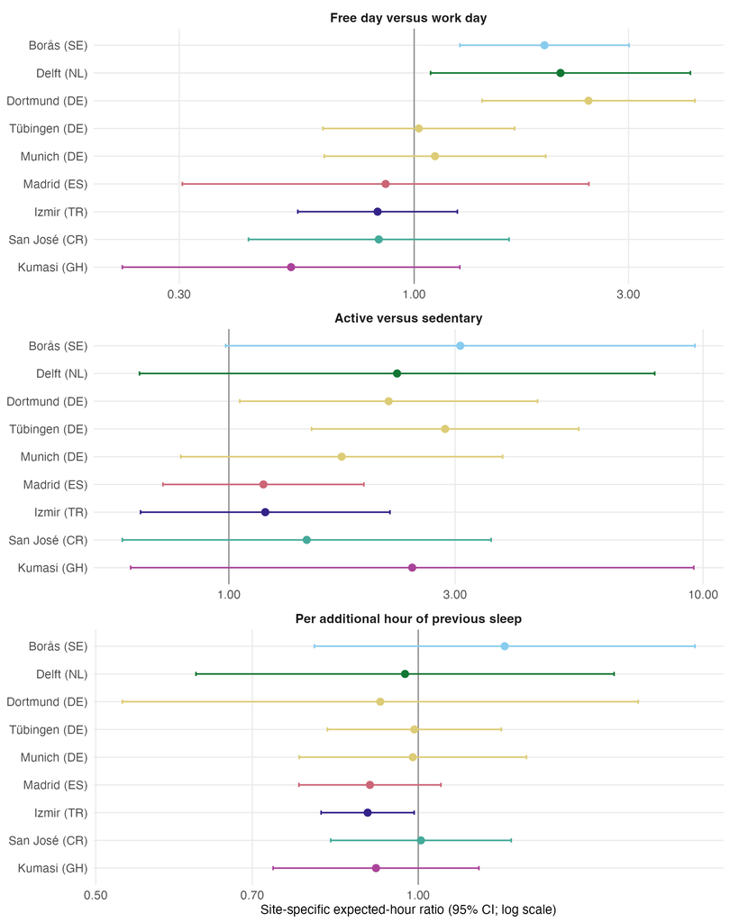

Site-specific descriptive estimates from the full primary interaction model. Site estimates receive no separate significance screening.

Source CSV

# Required data sensitivity

At first use, this report calls the comparison input the **gap-timing-unaware dataset**. It still passed the 50%-per-hour and 80%-per-day coverage rules, but the timing of remaining within-hour and within-day gaps was not used for an additional metric-specific adjustment. The primary analysis could therefore be interpreted as time-sensitive. After this one-time qualification, the current corrected input is called simply the **primary dataset**.

The all-available near-eye comparison has 16,329 hours, 702 participant-days, 137 participants, and nine sites. On the exact common-hour frame, the primary dataset drops 267 hours and the gap comparison drops none; 16,329 hour keys remain. Predictors are identical. Only 12 response values differ, so this is both a sample-composition and a response-construction check rather than a claim that the two inputs are identical.

Exact common-hour sample for the required data sensitivity.

| Placement | Primary hours | Gap-comparison hours | Exact common hours | Primary-only hours | Gap-only hours | Common days | Participants | Sites |
| --- | --- | --- | --- | --- | --- | --- | --- | --- |
| Near-eye | 16,596 | 16,329 | 16,329 | 267 | 0 | 702 | 137 | 9 |
| Chest | 18,352 | 18,112 | 18,112 | 240 | 0 | 777 | 149 | 8 |

Primary-versus-gap sensitivity on all available and exact common hours.

| Predictor | Primary | Gap | Primary adjusted p | Gap adjusted p |
| --- | --- | --- | --- | --- |
| All available |  |  |  |  |
| Free day versus work day | 1.45 × (1.14–1.85) | 1.44 × (1.14–1.82) | **0.004** | **0.004** |
| Active versus sedentary | 2.06 × (1.54–2.76) | 2.08 × (1.55–2.79) | **<0.001** | **<0.001** |
| Previous sleep duration (per hour) | 0.98 × (0.85–1.12) | 0.96 × (0.85–1.10) | 0.745 | 0.574 |
| Exact common hours |  |  |  |  |
| Free day versus work day | 1.44 × (1.14–1.81) | 1.44 × (1.14–1.82) | **0.004** | **0.004** |
| Active versus sedentary | 2.06 × (1.54–2.76) | 2.08 × (1.55–2.79) | **<0.001** | **<0.001** |
| Previous sleep duration (per hour) | 0.96 × (0.85–1.09) | 0.96 × (0.85–1.10) | 0.553 | 0.574 |

Each input retains its declared three-test BH family. Exact-common primary and gap models use identical hour keys.

All three estimates and multiplicity conclusions are stable. The gap near-eye ratios are 1.44 for free/work, 2.08 for active/sedentary, and 0.96 per hour of sleep. Work/free site heterogeneity also remains multiplicity-retained (BH-adjusted p = 0.015).

# Placement analyses

The all-available chest ratios are 1.51 (95% CI 1.21–1.89), 1.81 (1.28–2.54), and 0.95 (0.84–1.07). The paired-day sample contains the same 553 participant-days, 109 participants, and eight sites at each placement. Its near-eye ratios are 1.59, 1.96, and 0.96; chest ratios are 1.53, 1.82, and 0.95. These contextual intervals receive no new p-value family.

The paired-day frames each contain 12,842 hours, but only 12,839 hour keys are identical: three are near-eye-only and three are chest-only. REPORT-009’s identity scatter therefore does not apply. The figure shows side-by-side coefficient estimates, not observation-level identity. Similar directions do not establish placement equivalence.

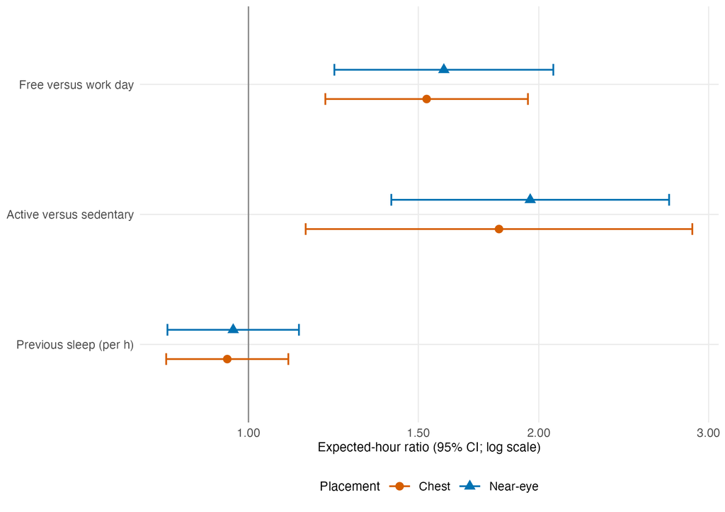

Near-eye and chest estimates on the paired-day sample. An identity scatter is not valid because three hourly keys differ at each placement.

Source CSV

# Diagnostics and limitations

All 12 approved additive/full fits converge; every fixed-effect design is full rank; and every unmodified HC3 matrix is finite and positive definite. The 48 HC0–HC3 covariance checks are also finite and positive definite. The largest condition number is 6,998. These results clear the numerical gate, not the scientific adequacy gate.

Interpreted diagnostics for the six additive mean models.

| Scenario | Zero hours | Dispersion | Observed/fitted decile range | Residual–fitted Spearman | \|Residual\|–fitted Spearman | Residual lag 1 | Residual lag 6 | Gate |
| --- | --- | --- | --- | --- | --- | --- | --- | --- |
| Primary near-eye | 28.3% | 3,617.867 | 0.78–1.61 | −0.564 | 0.553 | 0.464 | 0.013 | PASS |
| Chest, all available | 29.1% | 4,471.413 | 0.68–1.49 | −0.605 | 0.585 | 0.366 | −0.006 | PASS |
| Near-eye, paired days | 29.1% | 3,837.745 | 0.65–1.62 | −0.590 | 0.568 | 0.463 | 0.011 | PASS |
| Chest, paired days | 29.6% | 4,872.968 | 0.70–1.81 | −0.636 | 0.612 | 0.376 | −0.007 | PASS |
| Gap sensitivity, near-eye | 28.3% | 3,727.388 | 0.77–1.52 | −0.563 | 0.551 | 0.461 | 0.013 | PASS |
| Gap sensitivity, chest | 29.1% | 4,562.913 | 0.66–1.44 | −0.608 | 0.587 | 0.363 | −0.008 | PASS |

Calibration is in-sample and descriptive, not predictive validation. Dispersion is the Pearson working-dispersion estimate.

The primary response contains 28.3% exact-zero hours and the working dispersion is 3,618. Primary fitted-decile observed/fitted ratios range from 0.78 to 1.61. Residual–fitted Spearman correlation is −0.564 and absolute residual–fitted correlation is 0.553. These patterns indicate substantial mean–variance and mean-calibration limitations despite cluster-robust uncertainty.

Residual correlation remains 0.464 at lag 1 and 0.233 at lag 2 in the primary near-eye analysis; it approaches 0.013 by lag 6. Chest lag 1 is 0.366. Participant clustering permits this within-participant dependence for the covariance estimator, but does not claim that the hourly trajectory has been modeled. The residual-clock plot shows additional daytime structure. Because the approved estimand intentionally averages over observed supported hours, the confirmatory model does not add a post hoc clock term; this limitation is reported next to the estimate and the exploratory GAM supplies temporal context.

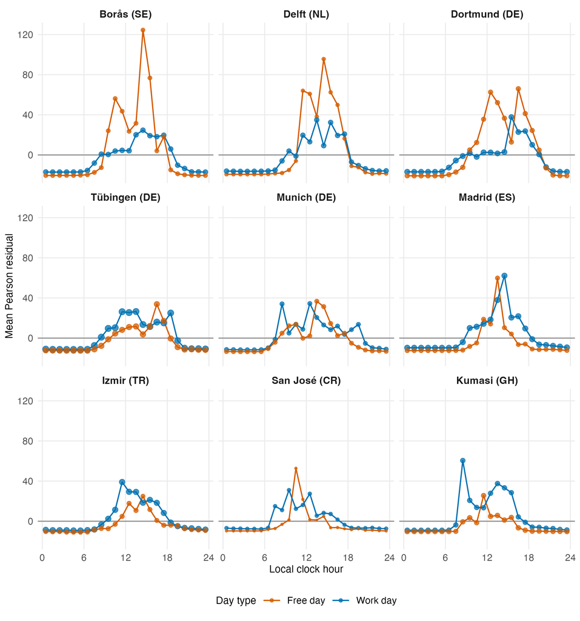

Source CSV

## Targeted influence checks

Seven score-ranked participants and all nine sites were deleted one at a time; all 16 refit sets converged with full-rank designs and positive-definite HC3 covariances. No participant or site was removed from the primary analysis.

Targeted participant and site deletion results.

| Type | Predictor | Largest shift (HC3 SE) | CIs excluding 1 |
| --- | --- | --- | --- |
| Participant deletion | Active versus sedentary | 0.487 | 7/7 |
| Participant deletion | Previous sleep duration (per hour) | 0.589 | 0/7 |
| Participant deletion | Free day versus work day | 0.532 | 7/7 |
| Site deletion | Active versus sedentary | 0.612 | 9/9 |
| Site deletion | Previous sleep duration (per hour) | 0.441 | 0/9 |
| Site deletion | Free day versus work day | 1.146 | 7/9 |

Activity excludes 1 in all 16 deletion checks; sleep excludes 1 in none. Work/free excludes 1 after every targeted participant deletion but after only 7 of 9 site deletions. Omitting Dortmund gives 1.26 (95% CI 0.98–1.62), and omitting Borås gives 1.34 (0.99–1.80). TUM S001 and the exploratory KNUST S005 row are not influential enough to explain the primary result.

## Working-variance, covariance, standardization, and day-type checks

The fixed-power quasi-Tweedie sensitivity (`p = 1.8`) materially changes the work/free conclusion: 1.15 (95% CI 0.91–1.45; BH-adjusted p = 0.260). Activity remains 1.91 (1.49–2.45; BH-adjusted p < 0.001), and sleep is 0.95 (0.88–1.04; BH-adjusted p = 0.260). Work/free heterogeneity remains multiplicity-retained (BH-adjusted p = 0.025). This is why the work/free result is classified as working-variance sensitive rather than robust.

HC1 and HC2 change uncertainty slightly but not the estimates or qualitative conclusions. Equal-site and observed-sample standardization coincide for the additive model. The weekday/weekend substitution gives a weekend/weekday ratio of 1.23 (95% CI 0.92–1.66); by contract it has an estimate and interval but no new p-value or multiplicity family.

Selected declared sensitivities for the three primary predictors.

| Predictor | Reference | Alternative | Classification |
| --- | --- | --- | --- |
| Quasi-Poisson vs p = 1.8 |  |  |  |
| Free day versus work day | 1.45 × (1.14–1.85) | 1.15 × (0.91–1.45) | multiplicity-conclusion-sensitive |
| Active versus sedentary | 2.06 × (1.54–2.76) | 1.91 × (1.49–2.45) | stable within model uncertainty |
| Previous sleep duration (per hour) | 0.98 × (0.85–1.12) | 0.95 × (0.88–1.04) | stable within model uncertainty |
| HC3 vs HC1 |  |  |  |
| Free day versus work day | 1.45 × (1.14–1.85) | 1.45 × (1.14–1.84) | stable within model uncertainty |
| Active versus sedentary | 2.06 × (1.54–2.76) | 2.06 × (1.55–2.74) | stable within model uncertainty |
| Previous sleep duration (per hour) | 0.98 × (0.85–1.12) | 0.98 × (0.86–1.11) | stable within model uncertainty |
| HC3 vs HC2 |  |  |  |
| Free day versus work day | 1.45 × (1.14–1.85) | 1.45 × (1.14–1.84) | stable within model uncertainty |
| Active versus sedentary | 2.06 × (1.54–2.76) | 2.06 × (1.55–2.75) | stable within model uncertainty |
| Previous sleep duration (per hour) | 0.98 × (0.85–1.12) | 0.98 × (0.86–1.11) | stable within model uncertainty |
| Equal-site vs observed sample |  |  |  |
| Free day versus work day | 1.45 × (1.14–1.85) | 1.45 × (1.14–1.85) | stable within model uncertainty |
| Active versus sedentary | 2.06 × (1.54–2.76) | 2.06 × (1.54–2.76) | stable within model uncertainty |
| Previous sleep duration (per hour) | 0.98 × (0.85–1.12) | 0.98 × (0.85–1.12) | stable within model uncertainty |

# V0 reconstruction and comparison

V0 deliberately fitted repeated hourly geometric mean melEDI with the fixed scaffold `geo.MEDI ~ site * daytype + site * exercise + site * sleep_duration + (1 | Id)`. The current immutable-pin reconstruction uses 16,500 near-eye and 18,218 chest hours. **Neither reconstructed V0 model is singular**: both converge, have positive-definite Hessians, and pass the stored singularity check. V0 is thus a mathematically valid candidate scaffold, not a failed fit.

It is not an adequate final H06 basis without revision. It uses four-level exercise rather than the approved binary activity contrast, repeats day-level predictors over hours without participant-day or residual temporal handling, uses model-based mixed-model uncertainty rather than the approved participant cluster inference, and does not implement the current hierarchy, multiplicity, site-standardization, or reporting contract. Its deliberate hourly intent is retained; the separable downstream errors are repaired.

The reconstructed near-eye free/work ratio is 0.94 (95% CI 0.85–1.02) and the sleep ratio is 0.93 per hour (0.90–0.96); chest values are 0.94 (0.86–1.03) and 0.92 (0.89–0.96). These differ from the revised population-mean results because the fitted rows, activity definition, dependence/uncertainty architecture, and estimand implementation differ. The frozen V0 table reported 0.92 for both free/work and sleep but did not retain 95% intervals.

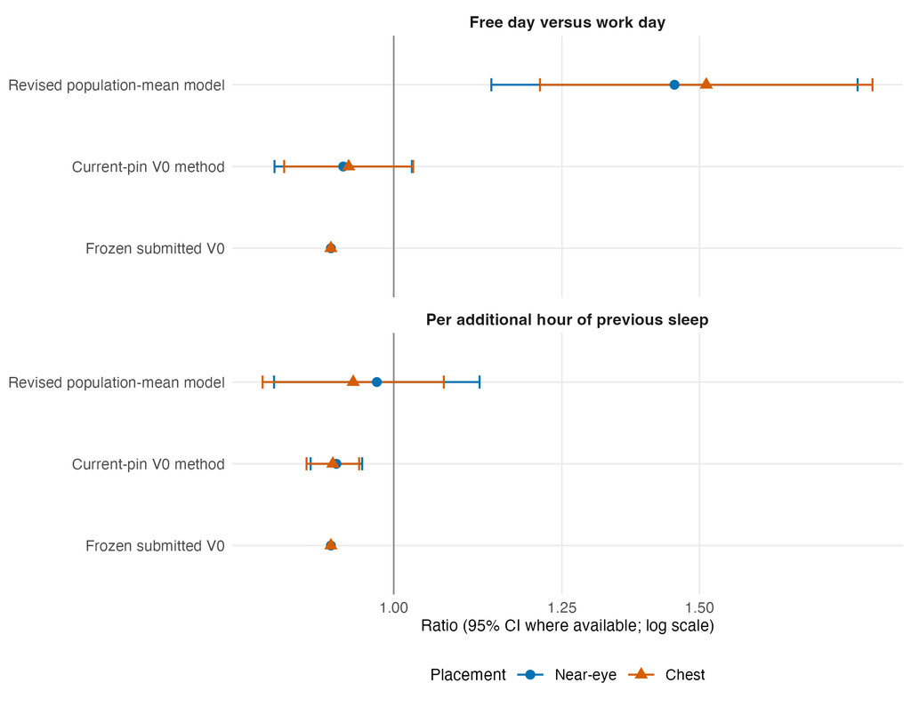

V0 and revised H06 estimates. Frozen V0 intervals cannot be recovered from the submitted table. Exercise is excluded because V0’s four levels do not match the approved binary activity contrast.

Source CSV

# Exploratory analyses

## Additional diary measures

These estimates are exploratory, use their own exact samples, and have no confirmatory p-values. They are not used to select or rescue the primary model.

Exploratory one-at-a-time diary associations; no p-value family.

| Effect | Ratio (95% CI) |
| --- | --- |
| Exercise indoors vs outdoors | 0.49 × (0.34–0.70) |
| Both locations vs outdoors | 0.77 × (0.37–1.62) |
| Active travel, per hour | 1.10 × (0.97–1.26) |
| Sedentary time, per hour | 0.98 × (0.93–1.03) |
| Sleep onset, per hour later | 0.87 × (0.73–1.05) |
| Wake time, per hour later | 0.87 × (0.73–1.05) |

Exploratory quasi-Poisson log means with participant-cluster HC3. No p-values are calculated or displayed.

## Exploratory time-of-day GAMs

The time-of-day analysis is a separate two-part model: a binomial-logit occurrence component for melEDI > 0 and a Gamma-log component for positive melEDI. Within each submitted site and work/free × activity combination, their product describes expected hourly melEDI. The day-type display averages those response-scale expected means with equal weight over sedentary and active status and over all nine sites. The activity display instead averages with equal weight over work and free days and over all nine sites. Both components use four cyclic factor-by clock smooths for work/free day × sedentary/active status, with one shared smoothing parameter (`id = 1`). The parametric work/free × activity interaction preserves hierarchy. Site enters only as a parametric fixed adjustment; there is no site-specific clock smooth and no `sz` component. Participant and participant-day random-effect smooths, true-sequence `AR.start`, and a working residual correlation remain. The selected basis is `k = 16`; all fits use `mgcv::bam(method = "fREML", discrete = TRUE)`. No H06 computation requires `discrete = FALSE`.

```r
two_part_formula_registry |>
  dplyr::select(
    Component = .data$component,
    Family = .data$response_family,
    `Evaluated Wilkinson formula` = .data$selected_formula,
    Method = .data$method,
    Discrete = .data$discrete,
    `Basis k` = .data$selected_basis_k
  ) |>
  compact_gt(
    source_note = paste0(
      "Exploratory only. Positive-magnitude sequences are rebuilt after ",
      "removing zero hours, so residual correlation never bridges a removed zero."
    )
  )
```

| Component | Family | Evaluated Wilkinson formula | Method | Discrete | Basis k |
| --- | --- | --- | --- | --- | --- |
| occurrence | Binomial occurrence with logit link | melEDI_positive ~ previous_sleep_duration_centered_h + site + work_free_day * activity_status + s(clock_hour, by = day_activity_group, bs = "cc", k = 16, id = 1) + s(participant_key, bs = "re") + s(pa… | fREML | TRUE | 16 |
| positive_magnitude | Gamma positive magnitude with log link | response_value ~ previous_sleep_duration_centered_h + site + work_free_day * activity_status + s(clock_hour, by = day_activity_group, bs = "cc", k = 16, id = 1) + s(participant_key, bs = "re") + s(par… | fREML | TRUE | 16 |

Exploratory only. Positive-magnitude sequences are rebuilt after removing zero hours, so residual correlation never bridges a removed zero.

The selected occurrence and positive-magnitude models converge with full-rank fixed-smooth designs. Working residual correlations are 0.418 and 0.440. Cyclic closure differences are at most 1.1 × 10^-16 for occurrence and 1.8 × 10^-15 for the combined expected mean. At `k = 16`, the four occurrence smooths use edf 7.95–9.80 of 14 available and have `k`-check p-values 0.013–0.023. Because edf remains well below the basis ceiling, this is retained as a residual/model-structure warning rather than interpreted as proof that a larger basis is required. Positive-magnitude `k`-check p-values are 0.18–0.21.

The occurrence model overpredicts the lowest fitted-probability decile (observed/fitted ratio 0.829). Positive-magnitude calibration spans roughly 0.89–1.21 and remains weakest in the positive tail. Changing from `k = 12` to `k = 16` produces a 95th-percentile relative difference of 15.1% for the combined expected curves. The curves therefore contextualize when exposure differs; they are not stable confirmatory whole-curve tests and receive no pointwise significance highlighting.

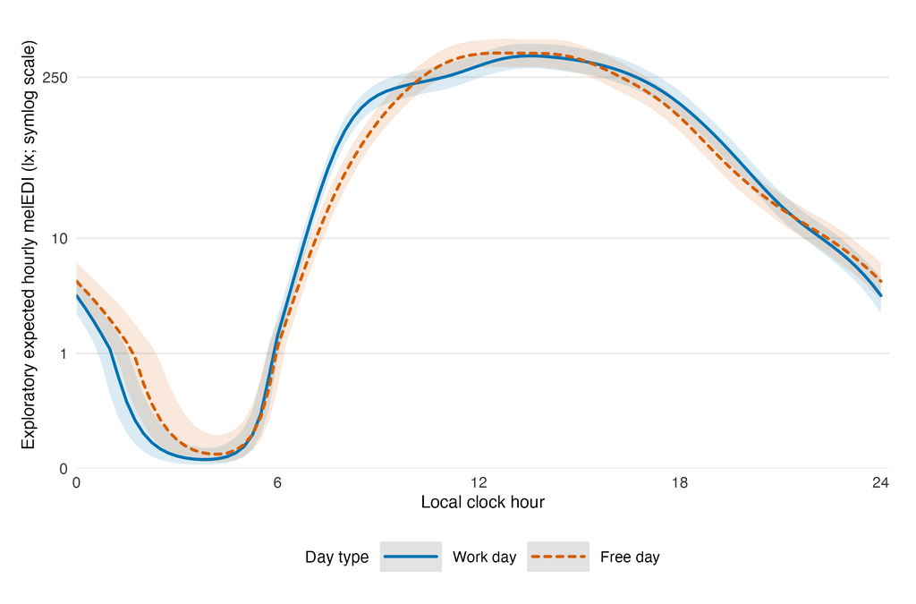

Exploratory expected melEDI by day type across local clock time, standardized with equal weight to sedentary and active status and to each of the nine submitted sites. Curves exclude participant and participant-day random effects; ribbons are approximate pointwise 95% intervals with smoothing parameters fixed and occurrence–magnitude cross-component covariance set to zero. These curves contextualize time of day and are separate from preregistered inference.

Source CSV

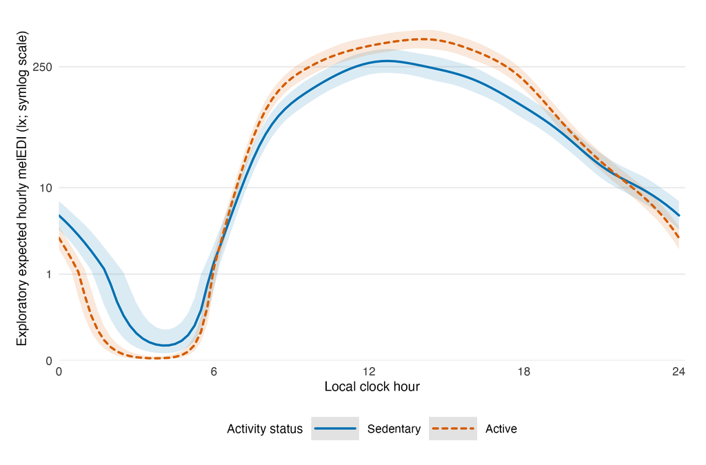

Exploratory expected melEDI by activity status across local clock time, standardized with equal weight to work and free days and to each of the nine submitted sites. Curves exclude participant and participant-day random effects; ribbons are approximate pointwise 95% intervals with smoothing parameters fixed and occurrence–magnitude cross-component covariance set to zero. These curves contextualize time of day and are separate from preregistered inference.

Source CSV

The occurrence component remains part of each expected-melEDI calculation but is not shown as a separate reader-facing figure.

# Figure readability and reproducibility

All seven reader-facing figures were assessed at 170 mm on an A4 portrait page with 20-mm side margins. Native and intended widths are equal, so the scale factor is 1. The five confirmatory/contextual figures retain 8-pt essential text; the two exploratory figures also retain 8 pt. Physical-size inspection found no clipping, overlap, harmful wrapping, distortion, or materially imbalanced data region.

REPORT-011 physical-size figure checks.

| Figure | Native width (mm) | Intended width (mm) | Scale factor | Smallest nominal text (pt) | Effective final text (pt) | Status |
| --- | --- | --- | --- | --- | --- | --- |
| H06_core_effects | 170 | 170 | 1 | 8 | 8 | PASS |
| H06_primary_site_effects | 170 | 170 | 1 | 8 | 8 | PASS |
| H06_V0_comparison | 170 | 170 | 1 | 8 | 8 | PASS |
| H06_primary_residual_clock | 170 | 170 | 1 | 8 | 8 | PASS |
| H06_paired_placement_effects | 170 | 170 | 1 | 8 | 8 | PASS |
| H06_exploratory_two_part_day_type_expected | 170 | 170 | 1 | 8 | 8 | PASS |
| H06_exploratory_two_part_activity_expected | 170 | 170 | 1 | 8 | 8 | PASS |

The analysis was run with R 4.6.1. Scientific transformations, checks, summaries, and models are implemented in H06-scoped R scripts. No package was installed, no shared data were edited, no heavy resampling was run, and no full-project render was used. The production command was:

```
Rscript --vanilla -e '.libPaths(c(normalizePath("renv/library/macos/R-4.6/aarch64-apple-darwin23"), .libPaths())); Sys.setenv(H06_STAGE="fit", H06_REUSE_FITS="true"); sys.source("scripts/hypotheses/H06/run_h06_stage2.R", envir=globalenv())'
```

# H06-G2 decisions requested

The recommended gate disposition is **approve Stage 2 with explicit qualifications**, not accept every provisional association as equally robust. Please decide whether to approve the following contract for Stage 3:

1. Accept the quasi-Poisson population-mean model with participant-cluster HC3 as the H06 primary implementation of the selected supported-hour estimand.
2. Accept the active-versus-sedentary association as stable across the declared dataset, placement, covariance, working-variance, and deletion checks, while retaining the observational interpretation.
3. Retain the free-versus-work association only with its working-variance, site-heterogeneity, and leave-site-out qualifications; do not call it a generally robust site-invariant association.
4. Report the previous-sleep result as inconclusive over the interval 0.85–1.12 per additional hour, not as evidence of no association.
5. Retain chest, paired-day, gap, weekday/weekend, additional-diary, and two-part GAM results only in their prespecified contextual, sensitivity, or exploratory roles.
6. Accept the documented mean-calibration, residual temporal, and local-clock limitations next to the results. No resampling is required for H06 Stage 2.